# Marxists Internet Archive LDA

fuente: https://github.com/DiegoKoz/MIA_text_mining

> Warning: Este dataset es muy pesado. Eso implica que lleva tiempo correr los modelos y que puede no entrar en la memoria de la computadora. Para la clase, se puede hacer un muestreo de textos para que no pese tanto

```r
library(tidyverse)
library(glue)
library(tm)
library(topicmodels)
library(tidytext)
library(stringi)
library(LDAvis)
library(slam)
library(tsne)
library(lubridate)
library(DT)
library(lsa)
library(igraph)
library(ggraph)
library(tidygraph)
```

```r
df <- read_csv('../data/txt/texto_limpio.txt')
# df <- read_rds('data/MIA.RDS')
df <- df %>%
  filter(tipo=='notas')
```

```r
df <- df %>%
  mutate(texto = tolower(texto),
         texto = stri_trans_general(texto, "Latin-ASCII"),
         texto = str_trim(texto,side = 'both'),
         texto = str_replace_all(texto,'\t',' '),
         texto = str_replace_all(texto,'\n',' '),
         texto = str_replace_all(texto,'\r',' '),
         texto = str_replace_all(texto,'[[:punct:]]',' '),
         texto = str_replace_all(texto,'\\d','NUM'),
         texto = str_replace_all(texto,'(NUM)+','NUM'),
         texto = str_replace_all(texto,"\\s+", " "))
```

Para topic modeling las palabras comunes de la lengua generan mucho ruido y terminan predominnado en los topicos.

Vamos a eliminar no solo las Stop Words, sino también las palabras más utilizadas en el español que no están relacionadas con nuestra temática. Para eso, tenemos un archivo r_words.txt donde pusimos todas las palabras más comunes.

Además, aprovechamos para eliminar los tokens que quedaron del scrapeo que en realidad son parte del código html (ver final del archivo).

¿de donde salieron estos tokens? En una primera iteración del LDA, uno de los tópicos que se armó era de código html.

```r
palabras_comunes <- read_csv(file = 'data/r_words.txt',col_names = F)
palabras_comunes <-stri_trans_general(palabras_comunes$X1, "Latin-ASCII") # le tengo que hacer la misma transformacion que al texto
stop_words <- stri_trans_general(stopwords(kind = "es"), "Latin-ASCII")

palabras_eliminar <- unique(c(stop_words,palabras_comunes))

rm(stop_words)
rm(palabras_comunes)
gc()
```

```
           used  (Mb) gc trigger  (Mb) max used  (Mb)
Ncells  2257074 120.6    4118112 220.0  4118112 220.0
Vcells 12707727  97.0   40287778 307.4 33501743 255.6
```

```r
Corpus = VCorpus(VectorSource(df$texto))
Corpus = tm_map(Corpus, removeWords, palabras_eliminar)
# Corpus <- tm_map(Corpus, stemDocument, language = "spanish") # Corpus

dtm <- DocumentTermMatrix(Corpus)
rm(Corpus)
gc()
# tm::nTerms(dtm)
#elimino los docuemntos vacios
# rowTotals <- rowSums(as.matrix(dtm))
# nDocs(dtm)
# dtm   <- dtm[rowTotals> 0, ]
# nDocs(dtm)

write_rds(dtm, 'data/dtm_MIA.rds')

# df <- df[which(rowTotals>0),] #%>%  #tengo que eliminar ese docuemnto que estaba vacio
```

```r
dtm <- read_rds('data/dtm_MIA.rds')
```

limpio la memoria porque ya no me queda espacio

```r
rm(palabras_eliminar)
gc()
```

```
           used  (Mb) gc trigger  (Mb) max used  (Mb)
Ncells  2464865 131.7    4117968 220.0  4117968 220.0
Vcells 17803739 135.9   40281786 307.4 40176737 306.6
```

```r
lda_fit <- LDA(dtm, k = 20,method = "Gibbs", control = list(delta=0.6,seed = 1234))
lda_fit

saveRDS(lda_fit, 'modelos/MIA_lda20.rds') # Tarda mucho en correr, asi que guardamos los resultados
```

```r
lda_fit <- read_rds('modelos/MIA_lda20.rds')
```

```r
Terms
```

```
      Topic 1       Topic 2             Topic 3     Topic 4      Topic 5         Topic 6        Topic 7           Topic 8       Topic 9
 [1,] "rda"         "num"               "num"       "pci"        "https"         "nbsp"         "decisivamente"   "conveniente" "turcos"
 [2,] "rfa"         "numpt"             "stalin"    "chirac"     "conmemorar"    "orwell"       "encontraran"     "mazzini"     "ayudarlo"
 [3,] "gorbachov"   "pnum"              "trotsky"   "miterrand"  "credenciales"  "carnaval"     "atrapados"       "contemplan"  "posible"
 [4,] "kohl"        "numcm"             "moscu"     "kostas"     "expulsados"    "zamiatin"     "respuesta"       "feliz"       "raices"
 [5,] "perestroika" "escritos"          "comite"    "lambert"    "germinal"      "risa"         "adicionales"     "formuladas"  "agresivos"
 [6,] "erich"       "titulo"            "oposicion" "mppt"       "resueltamente" "rabelais"     "alentadora"      "noveno"      "agrupamientos"
 [7,] "honecker"    "tituloescritosnum" "lenin"     "seljouk"    "sorge"         "comica"       "anonimo"         "sincera"     "aseguraba"
 [8,] "glasnost"    "sectionnum"        "gpu"       "pcf"        "usurpadora"    "carnavalesca" "apoyarlos"       "althusser"   "carnales"
 [9,] "muro"        "tnum"              "central"   "ordenanzas" "veraz"         "tambi"        "aqueronte"       "asegurarse"  "cipacion"
[10,] "sed"         "oposicion"         "carta"     "rpr"        "alquileres"    "car"          "arbitrariedades" "beber"       "desafiado"
      Topic 10    Topic 11          Topic 12     Topic 13       Topic 14    Topic 15        Topic 16    Topic 17     Topic 18   Topic 19
 [1,] "bolivia"   "longuet"         "ejercito"   "num"          "espana"    "indoamericana" "lenin"     "argentina"  "china"    "num"
 [2,] "lora"      "cargo"           "frente"     "pueblo"       "poum"      "constituian"   "carta"     "mariategui" "mao"      "trabajo"
 [3,] "iglesia"   "combino"         "rojo"       "gobierno"     "hombres"   "devolucion"    "revista"   "peron"      "chino"    "produccion"
```

[output cut: 18 more lines]

```r
diccionario <- tibble(
n_topico = 1:20,
nombre_topico = c('perestroika','formato','interna_bolche','pcf','expulsados','orwell','?','althusser','turcos','bolivia','longuet','ejercito','chile','españa','indoamericana','lenin','argentina','china','trabajo_prod','partido')
)
```

Visualizacion

```r
topicmodels_json_ldavis <- function(fitted, dtm){
    svd_tsne <- function(x) tsne(svd(x)$u)

    # Find required quantities
    phi <- as.matrix(posterior(fitted)$terms)
    theta <- as.matrix(posterior(fitted)$topics)
    vocab <- colnames(phi)
    term_freq <- slam::col_sums(dtm)

    # Convert to json
    json_lda <- LDAvis::createJSON(phi = phi, theta = theta,
                            vocab = vocab,
                            mds.method = svd_tsne,
                            plot.opts = list(xlab="tsne", ylab=""),
                            doc.length = as.vector(table(dtm$i)),
                            term.frequency = term_freq)

    return(json_lda)
}
```

```r
serVis(json_res, out.dir = 'lda_viz,html')
```

```
To stop the server, run servr::daemon_stop(1) or restart your R session
Serving the directory /home/diego/Documents/0_GIT/6_Miscelaneos/MIA_text_mining/LDA/lda_viz,html at http://127.0.0.1:4321
```

```r
serVis(json_res,as.gist = T)
```

# Se puede calcular el tema del que habla en promedio cada autor.

```r
dist_topicos <- df  %>%
  select(autor, fecha) %>%
  bind_cols(as_tibble(as.matrix(posterior(lda_fit)$topics)))

dist_topicos <- dist_topicos %>%
  group_by(autor) %>%
  summarise_all(~mean(.x, na.rm = T)) %>%
  mutate(fecha=round(fecha))


names(dist_topicos)[3:22] <- diccionario$nombre_topico

dist_topicos %>%
  filter(!is.na(fecha)) %>%
datatable(., filter = 'top',extensions = 'Buttons', options = list(dom = 'Bfrtip',  buttons = c('excel', "csv", "copy", "pdf"),   pageLength = 20, autoWidth = TRUE),rownames= FALSE) %>%
  formatPercentage(diccionario$nombre_topico, 2) %>%
  formatStyle(diccionario$nombre_topico, background = styleColorBar(c(0,1), 'deepskyblue')) %>%
  formatStyle(diccionario$nombre_topico,
              backgroundSize = '98% 60%',
              backgroundRepeat = 'no-repeat',
              backgroundPosition = 'center')
```

| autor | fecha | perestroika | formato | interna_bolche | pcf | expulsados | orwell | ? | althusser | turcos | bolivia | longuet | ejercito | chile | españa | indoamericana | lenin | argentina | china | trabajo_prod | partido |
| --- | --- | --- | --- | --- | --- | --- | --- | --- | --- | --- | --- | --- | --- | --- | --- | --- | --- | --- | --- | --- | --- |
| Albert Mathiez | 1920 | 0.00517384105960265 | 0.00310430463576159 | 0.0747102649006623 | 0.00269039735099338 | 0.00475993377483444 | 0.00103476821192053 | 0.00186258278145695 | 0.00103476821192053 | 0.00103476821192053 | 0.00186258278145695 | 0.00227649006622517 | 0.0718129139072848 | 0.039114238410596 | 0.0035182119205298 | 0.00310430463576159 | 0.00517384105960265 | 0.00310430463576159 | 0.00186258278145695 | 0.232408940397351 | 0.540355960264901 |
| Albert Rhys Williams | 1921 | 0.0051487414187643 | 0.0040045766590389 | 0.182494279176201 | 0.0085812356979405 | 0.0062929061784897 | 0.0108695652173913 | 0.0074370709382151 | 0.0040045766590389 | 0.0028604118993135 | 0.0051487414187643 | 0.0097254004576659 | 0.1058352402746 | 0.0486270022883295 | 0.203089244851259 | 0.0051487414187643 | 0.0062929061784897 | 0.0165903890160183 | 0.0097254004576659 | 0.0131578947368421 | 0.344965675057208 |
| Alberto Flores Galindo | 1979 | 0.00586439111517115 | 0.0397851947743732 | 0.0515233815680957 | 0.00473833840154239 | 0.00370941370099938 | 0.00448495171120675 | 0.00516795744937414 | 0.00482484531963486 | 0.00463302303636242 | 0.00627154832509615 | 0.00577707430623664 | 0.0105009849219539 | 0.112203028299015 | 0.0143738328672616 | 0.00538096429713827 | 0.00787121611358066 | 0.170490157951808 | 0.00385029203263355 | 0.12157133473123 | 0.416978069077286 |
| Alejandra Kollontai | 1917 | 0.00721503883845803 | 0.00850056375671345 | 0.032058935221658 | 0.00683472640674454 | 0.00890946774020894 | 0.00755297584754027 | 0.00834095121352838 | 0.00949798146196129 | 0.00747047765057474 | 0.012308559341648 | 0.00644353846978504 | 0.0184525975949521 | 0.0352190985669917 | 0.0326571636748252 | 0.00772184366502848 | 0.0106631139843793 | 0.00687325528222614 | 0.00632597838859385 | 0.51717703652127 | 0.249776696372913 |
| Aleksandr Voronsky | 1925 | 0.0593220338983051 | 0.127118644067797 | 0.0423728813559322 | 0.0423728813559322 | 0.0423728813559322 | 0.0423728813559322 | 0.0593220338983051 | 0.0423728813559322 | 0.0593220338983051 | 0.0423728813559322 | 0.0423728813559322 | 0.0423728813559322 | 0.0423728813559322 | 0.0423728813559322 | 0.0423728813559322 | 0.0423728813559322 | 0.0593220338983051 | 0.0423728813559322 | 0.0423728813559322 | 0.0423728813559322 |
| Amadeo Bordiga | 1921 | 0.00619517842764959 | 0.00506847007687865 | 0.00997679071744626 | 0.00366597090394993 | 0.00477833309752267 | 0.00540356792350163 | 0.00477775087287785 | 0.00650276112763249 | 0.00611957817193278 | 0.00562185749836874 | 0.00397468850160242 | 0.00693582225111678 | 0.0255080439816954 | 0.00450454845265838 | 0.00611813738613076 | 0.00670414569498312 | 0.00744871809141619 | 0.00451655299281063 | 0.157039156646241 | 0.719139927183585 |
| Ana Pauker | 1947 | 0.0369649805447471 | 0.157587548638132 | 0.0797665369649805 | 0.0642023346303502 | 0.0408560311284047 | 0.0330739299610895 | 0.0252918287937743 | 0.0136186770428016 | 0.0175097276264591 | 0.0291828793774319 | 0.0214007782101167 | 0.0291828793774319 | 0.0486381322957198 | 0.0252918287937743 | 0.0408560311284047 | 0.0408560311284047 | 0.0214007782101167 | 0.0175097276264591 | 0.0252918287937743 | 0.231517509727626 |
| Anatoli Lunacharsky | 1921 | 0.00932242542499074 | 0.0156771284463631 | 0.0977496088098808 | 0.0085392986303567 | 0.00854475248772797 | 0.00804183929604977 | 0.00878012868026205 | 0.00618812978798332 | 0.00782254108325686 | 0.00573765778864493 | 0.00957322287815809 | 0.0412428554213637 | 0.0650046074931989 | 0.0939926705860391 | 0.00824514868203165 | 0.0247168012977505 | 0.00738770751874388 | 0.00822500426960923 | 0.339877900333121 | 0.225330571084467 |
| Andreu Nin | 1933 | 0.00406839244046216 | 0.00576893423247037 | 0.0120741243044939 | 0.0047719516954986 | 0.00459554143189939 | 0.00484271875884738 | 0.0043660752951545 | 0.00510877233849458 | 0.00432772631793518 | 0.00381634323341114 | 0.0040643107838522 | 0.00815296973857798 | 0.021836694969158 | 0.0574512345617827 | 0.0042980994949226 | 0.00503838120175701 | 0.003913267943347 | 0.00440611767481564 | 0.0397869646945709 | 0.797311378888549 |
| Anton Pannekoek | 1929 | 0.00243548808150256 | 0.0054640566942818 | 0.00396330113103754 | 0.00240297697687632 | 0.00230977899236705 | 0.00314062791562097 | 0.00220649596663811 | 0.00281440857646728 | 0.00239664336803751 | 0.00263731541733363 | 0.00256119821147823 | 0.0036677457460469 | 0.00961704519948014 | 0.00319951159938005 | 0.00227962484580847 | 0.00251941426276269 | 0.00240800189361906 | 0.00214154788472918 | 0.318956855374015 | 0.622877961862517 |

[output cut: 127 more lines]

```r
NA
```

```r
topicos_tsne <- tsne(dist_topicos[3:12],k = 2)
```

```
sigma summary: Min. : 0.276662517585559 |1st Qu. : 0.342100487112649 |Median : 0.380374992579688 |Mean : 0.438777732523355 |3rd Qu. : 0.477932564404244 |Max. : 1.25538282142226 |
Epoch: Iteration #100 error is: 14.7975036604591
Epoch: Iteration #200 error is: 0.661802933712387
Epoch: Iteration #300 error is: 0.651408283855638
Epoch: Iteration #400 error is: 0.63593167966367
Epoch: Iteration #500 error is: 0.633912108690681
Epoch: Iteration #600 error is: 0.633889159698047
Epoch: Iteration #700 error is: 0.633889017603302
Epoch: Iteration #800 error is: 0.633889017109474
Epoch: Iteration #900 error is: 0.633889017106043
Epoch: Iteration #1000 error is: 0.633889017106018
```

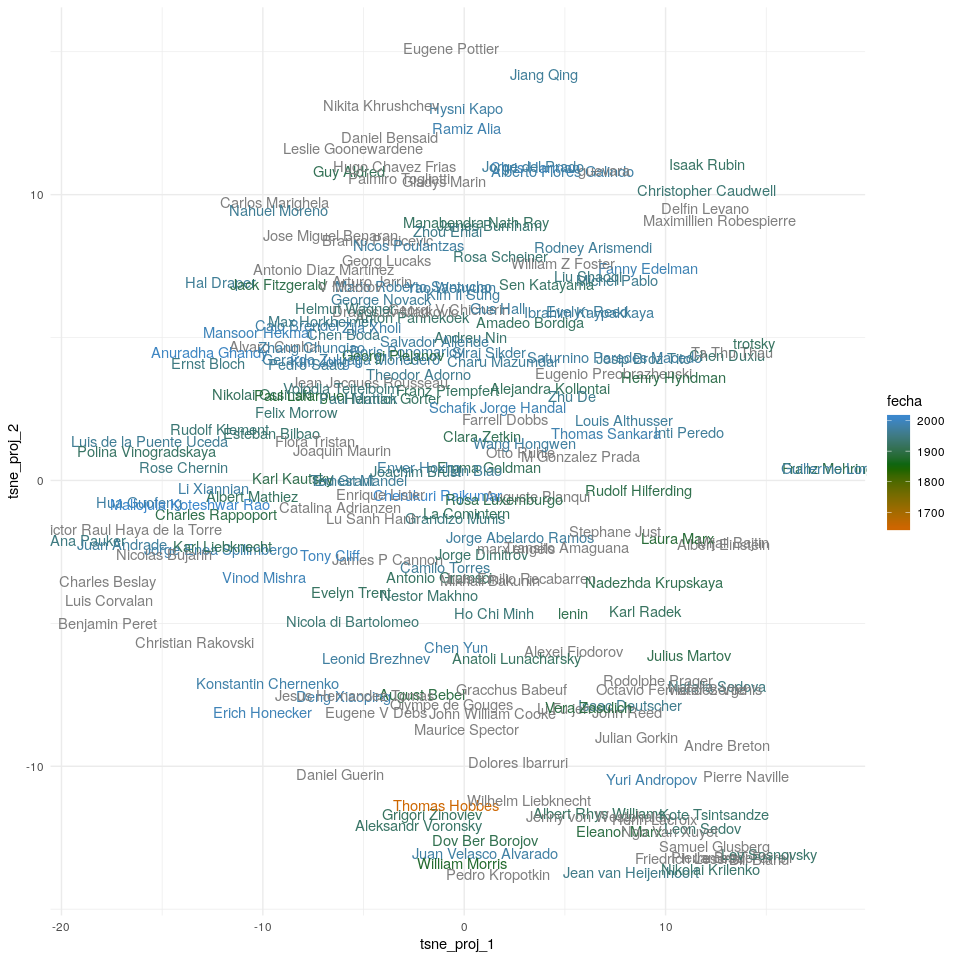

```r
topicos_tsne <- as_tibble(topicos_tsne,.name_repair = ~glue('tsne_proj_{c(1,2)}'))

dist_topicos %>% bind_cols(topicos_tsne) %>%
  ggplot(aes(tsne_proj_1,tsne_proj_2, label=autor, color=fecha)) +
  geom_text()+
  theme_minimal()+
  scale_color_gradient2(low = 'darkorange3',mid ='darkgreen' , high = 'dodgerblue', midpoint = 1850)
```

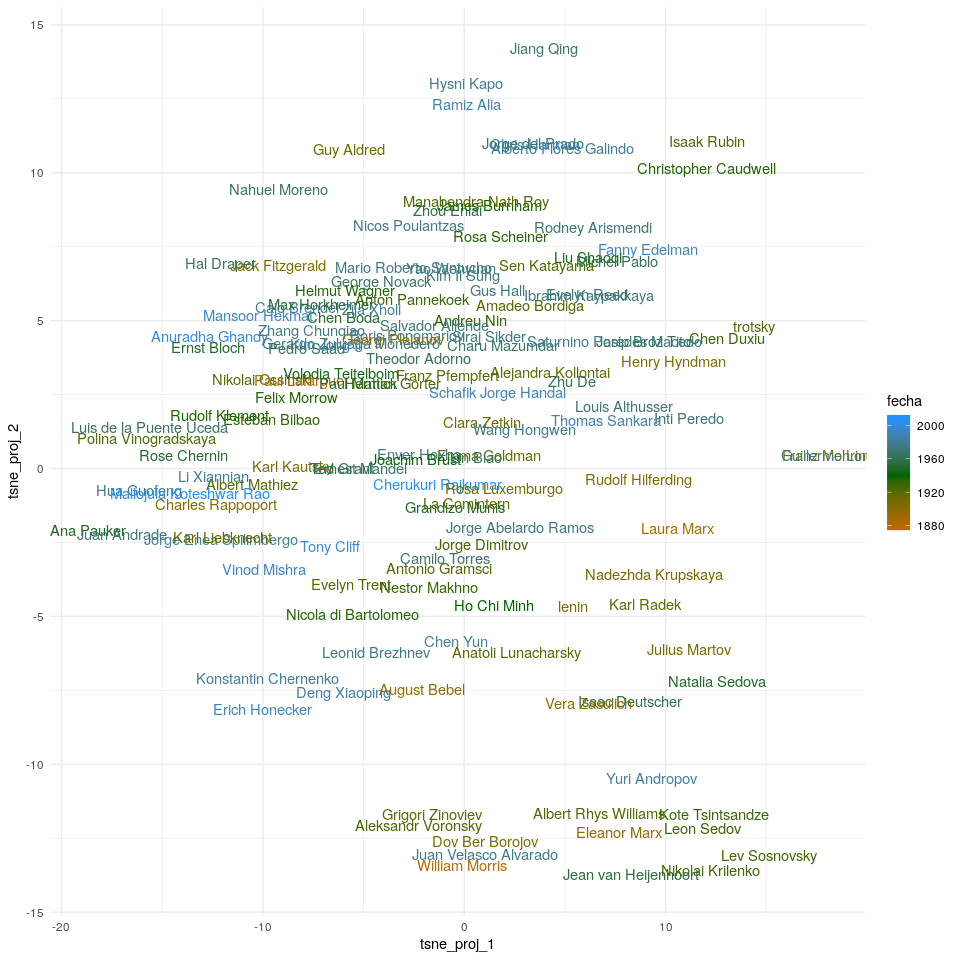

```r
dist_topicos %>% bind_cols(topicos_tsne) %>%
  filter(!is.na(fecha), fecha>1800) %>%
  ggplot(aes(tsne_proj_1,tsne_proj_2, label=autor, color=fecha)) +
  geom_text()+
  theme_minimal()+
  scale_color_gradient2(low = 'darkorange3',mid ='darkgreen' , high = 'dodgerblue', midpoint = 1940)
```

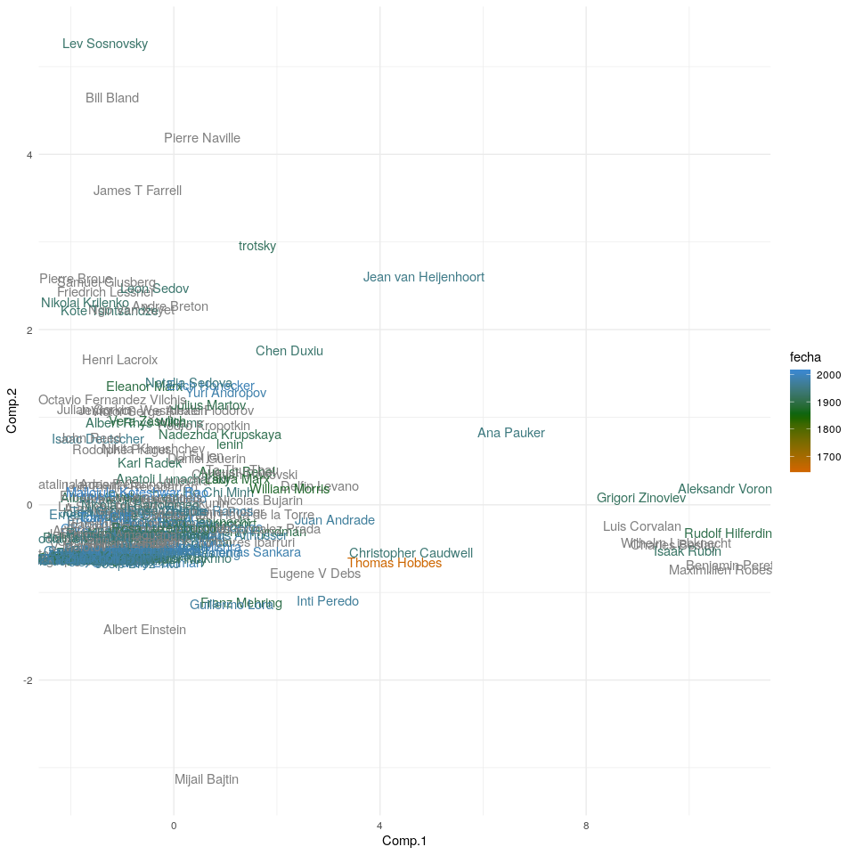

```r
topicos_pca <- princomp(dist_topicos[3:12], cor = TRUE)

dist_topicos %>% bind_cols(as_tibble(topicos_pca$scores[,1:2])) %>%
  ggplot(aes(Comp.1,Comp.2, label=autor, color = fecha)) +
  geom_text()+
  theme_minimal()+
  scale_color_gradient2(low = 'darkorange3',mid ='darkgreen' , high = 'dodgerblue', midpoint = 1850)
```

```r
NA
NA
```

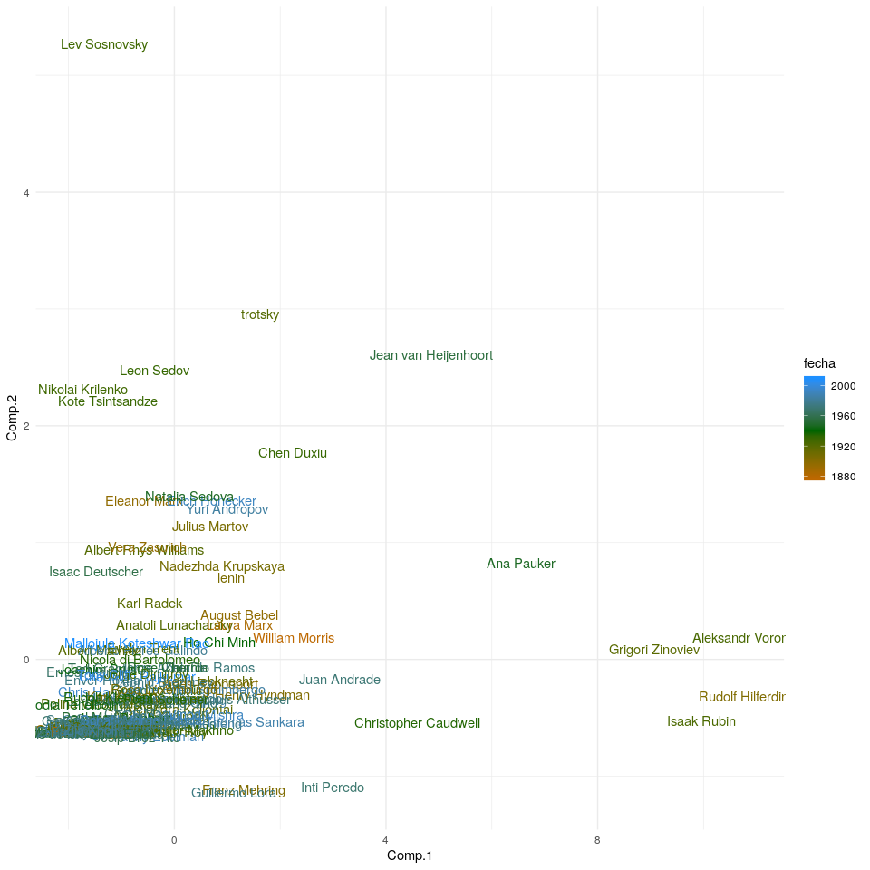

```r
dist_topicos %>% bind_cols(as_tibble(topicos_pca$scores[,1:2])) %>%
  filter(!is.na(fecha),fecha>1800) %>%
  ggplot(aes(Comp.1,Comp.2, label=autor, color = fecha)) +
  geom_text()+
  theme_minimal()+
  scale_color_gradient2(low = 'darkorange3',mid ='darkgreen' , high = 'dodgerblue', midpoint = 1940)
```

## Por fecha

```r
dist_topicos <- df  %>%
  select(autor, fecha) %>%
  bind_cols(as_tibble(as.matrix(posterior(lda_fit)$topics)))


names(dist_topicos)[3:22] <- diccionario$nombre_topico
```

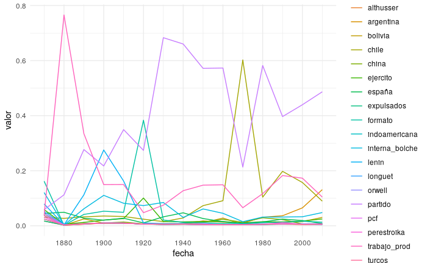

```r
dist_topicos %>%
  select(-autor) %>%
  mutate(fecha= round(fecha, -1)) %>%
  group_by(fecha) %>%
  summarise_all(~mean(.x, na.rm = T)) %>%
  filter(!is.na(fecha), fecha>1800) %>%
  gather(topico, valor,2:21) %>%
  mutate(topico=factor(topico)) %>%
  ggplot(aes(fecha, valor, group=topico, color=topico, fill=topico))+
  geom_line()+
  scale_x_continuous(breaks = scales::pretty_breaks(10))+
  # directlabels::geom_dl(aes(label = topico), method=list("top.qp", cex = .75))+
  theme_minimal()
```

```r
  # theme(legend.position = 'none')
```

```r
Terms
```

```
      Topic 1       Topic 2             Topic 3     Topic 4      Topic 5         Topic 6        Topic 7           Topic 8       Topic 9
 [1,] "rda"         "num"               "num"       "pci"        "https"         "nbsp"         "decisivamente"   "conveniente" "turcos"
 [2,] "rfa"         "numpt"             "stalin"    "chirac"     "conmemorar"    "orwell"       "encontraran"     "mazzini"     "ayudarlo"
 [3,] "gorbachov"   "pnum"              "trotsky"   "miterrand"  "credenciales"  "carnaval"     "atrapados"       "contemplan"  "posible"
 [4,] "kohl"        "numcm"             "moscu"     "kostas"     "expulsados"    "zamiatin"     "respuesta"       "feliz"       "raices"
 [5,] "perestroika" "escritos"          "comite"    "lambert"    "germinal"      "risa"         "adicionales"     "formuladas"  "agresivos"
 [6,] "erich"       "titulo"            "oposicion" "mppt"       "resueltamente" "rabelais"     "alentadora"      "noveno"      "agrupamientos"
 [7,] "honecker"    "tituloescritosnum" "lenin"     "seljouk"    "sorge"         "comica"       "anonimo"         "sincera"     "aseguraba"
 [8,] "glasnost"    "sectionnum"        "gpu"       "pcf"        "usurpadora"    "carnavalesca" "apoyarlos"       "althusser"   "carnales"
 [9,] "muro"        "tnum"              "central"   "ordenanzas" "veraz"         "tambi"        "aqueronte"       "asegurarse"  "cipacion"
[10,] "sed"         "oposicion"         "carta"     "rpr"        "alquileres"    "car"          "arbitrariedades" "beber"       "desafiado"
      Topic 10    Topic 11          Topic 12     Topic 13       Topic 14    Topic 15        Topic 16    Topic 17     Topic 18   Topic 19
 [1,] "bolivia"   "longuet"         "ejercito"   "num"          "espana"    "indoamericana" "lenin"     "argentina"  "china"    "num"
 [2,] "lora"      "cargo"           "frente"     "pueblo"       "poum"      "constituian"   "carta"     "mariategui" "mao"      "trabajo"
 [3,] "iglesia"   "combino"         "rojo"       "gobierno"     "hombres"   "devolucion"    "revista"   "peron"      "chino"    "produccion"
```

[output cut: 18 more lines]

## grafo de autores

```r
dist_topicos_autor <- dist_topicos %>%
  group_by(autor) %>%
  summarise_all(~mean(.x, na.rm = T)) %>%
  mutate(fecha=round(fecha))

adjMat = cosine(t(as.matrix(dist_topicos_autor[,3:21])))

colnames(adjMat) <- dist_topicos_autor$autor
rownames(adjMat) <- dist_topicos_autor$autor

adjMat[1:5,1:5]
```

```
                       Albert Einstein Albert Mathiez Albert Rhys Williams Alberto Flores Galindo Alejandra Kollontai
Albert Einstein             1.00000000      0.9050784           0.06238134              0.5092142           0.9908693
Albert Mathiez              0.90507840      1.0000000           0.35314499              0.5972952           0.9351204
Albert Rhys Williams        0.06238134      0.3531450           1.00000000              0.3230488           0.1524489
Alberto Flores Galindo      0.50921415      0.5972952           0.32304878              1.0000000           0.5509784
Alejandra Kollontai         0.99086935      0.9351204           0.15244893              0.5509784           1.0000000
```

```r
fivenum(adjMat)
```

```
[1] 0.007718294 0.318669415 0.513154724 0.767918635 1.000000000
```

```r
#la paso a dicotomica, no quiero que me quede muy densa, asi que pongo como punto de corte un valor alto

adjMat[adjMat>0.9] <- 1

adjMat[adjMat<0.9] <- 0

adjMat[1:5,1:5]
```

```
                       Albert Einstein Albert Mathiez Albert Rhys Williams Alberto Flores Galindo Alejandra Kollontai
Albert Einstein                      1              1                    0                      0                   1
Albert Mathiez                       1              1                    0                      0                   1
Albert Rhys Williams                 0              0                    1                      0                   0
Alberto Flores Galindo               0              0                    0                      1                   0
Alejandra Kollontai                  1              1                    0                      0                   1
```

```r
g = graph_from_adjacency_matrix(adjMat, weighted= NULL, mode="undirected", diag=FALSE)

V(g)$fecha <- dist_topicos_autor$fecha #agrego la fecha como atributo de cada autor
```

```r
mean(degree(g))
```

```
[1] 30.58768
```

```
partial argument match of 'length' to 'length.out'partial argument match of 'frame' to 'frame.plot'
```

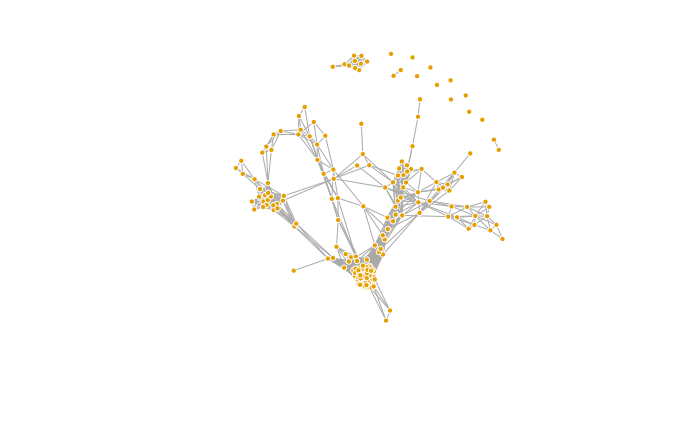

```r
l <- layout_nicely(g)

plot(g,edge.arrow.size=.2, vertex.size=4,vertex.frame.color="#ffffff",
             vertex.label="", vertex.label.color="black",
             layout=l)
```

```
Using `nicely` as default layout
```

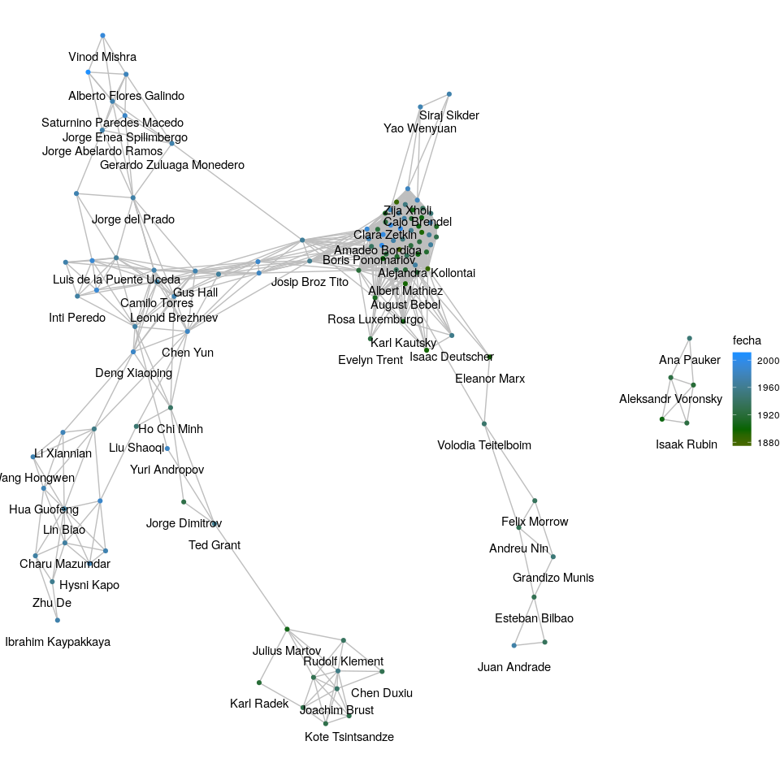

```r
as_tbl_graph(g) %>%
  filter(fecha>1800) %>%
  activate(nodes) %>%
  mutate(importance = centrality_degree()) %>%
  filter(importance >1) %>%
# as_tbl_graph(g) %>%
#   filter(fecha>1800,
#          !degree(g)<2) %>%
ggraph() +
    geom_edge_link(color='grey') +
    geom_node_point(aes(color=fecha))+
    geom_node_text(aes(label=name),check_overlap = T,nudge_y =-.5 ) +
  theme_void()+
  scale_color_gradient2(low = 'darkorange3',mid ='darkgreen' , high = 'dodgerblue', midpoint = 1900)
```